# R Lab 6 Key

## Setting Up

For this week, you will be working a “mega-lab”. What makes it mega? This lab does not cover any new content. Instead, it covers the all of the main concepts in R we have worked on so far.

### Libraries

```r
library(tidyverse)
library(ggplot2)
library(psych)
library(viridis)
library(palmerpenguins)
```

### Data: Penguins

This week we will be using data from the `palmerpenguins` library. The `penguins` dataset already comes inside the library, so by loading the library in the above code chunk we now have access to the data.

Using `glimpse` we can peek at the data structure and the variables in the dataset.

```r
glimpse(penguins)
```

```
## Rows: 344
## Columns: 8
## $ species           <fct> Adelie, Adelie, Adelie, Adelie, Adelie, Adelie, Adel…
## $ island            <fct> Torgersen, Torgersen, Torgersen, Torgersen, Torgerse…
## $ bill_length_mm    <dbl> 39.1, 39.5, 40.3, NA, 36.7, 39.3, 38.9, 39.2, 34.1, …
## $ bill_depth_mm     <dbl> 18.7, 17.4, 18.0, NA, 19.3, 20.6, 17.8, 19.6, 18.1, …
## $ flipper_length_mm <int> 181, 186, 195, NA, 193, 190, 181, 195, 193, 190, 186…
## $ body_mass_g       <int> 3750, 3800, 3250, NA, 3450, 3650, 3625, 4675, 3475, …
## $ sex               <fct> male, female, female, NA, female, male, female, male…
## $ year              <int> 2007, 2007, 2007, 2007, 2007, 2007, 2007, 2007, 2007…
```

## Descriptive Statistics

First, I want us to compare and contrast the mean versus the median `body_mass_g` of the penguins.

### EXERCISE 1: Mean body_mass_g

Below, compute the mean `body_mass_g` of the penguins. *hint*: do not forget to set na.rm = TRUE.

```r
mean(penguins$body_mass_g, na.rm = TRUE)
```

```
## [1] 4201.754
```

### EXERCISE 2: Median body_mass_g

Below, compute the median `body_mass_g` of the penguins. *hint*: do not forget to set na.rm = TRUE.

```r
median(penguins$body_mass_g, na.rm = TRUE)
```

```
## [1] 4050
```

### EXERCISE 3: Mean versus Median body_mass_g

Compare the mean versus the median. Which value is higher? What can we conclude from that?

The mean is higher at 4201 (median is 4050). We can conclude that we have some higher more extreme weight scores that are dragging the mean up. The median is not influenced by extreme scores and that is why it is 4050.

### EXERCISE 4: Standard Deviation body_mass_g

Below, compute the standard deviation `body_mass_g` of the penguins. *hint*: do not forget to set na.rm = TRUE.

```r
sd(penguins$body_mass_g, na.rm = TRUE)
```

```
## [1] 801.9545
```

### EXERCISE 5: Interpret how this standard deviation relates to the body_mass_g data and its mean.

Response: The mean `body_mass_g` is 4201.754 grams. The standard deviation is 801.9545 grams. The SD is approximately 20% of the mean score. This means that the SD is not extremely large and the scores tend to be clustered around the mean.

By running the below code, we can see that our calculations were correct!

```r
describe(penguins)
```

```
##                   vars   n    mean     sd  median trimmed    mad    min    max
## species*             1 344    1.92   0.89    2.00    1.90   1.48    1.0    3.0
## island*              2 344    1.66   0.73    2.00    1.58   1.48    1.0    3.0
## bill_length_mm       3 342   43.92   5.46   44.45   43.91   7.04   32.1   59.6
## bill_depth_mm        4 342   17.15   1.97   17.30   17.17   2.22   13.1   21.5
## flipper_length_mm    5 342  200.92  14.06  197.00  200.34  16.31  172.0  231.0
## body_mass_g          6 342 4201.75 801.95 4050.00 4154.01 889.56 2700.0 6300.0
## sex*                 7 333    1.50   0.50    2.00    1.51   0.00    1.0    2.0
## year                 8 344 2008.03   0.82 2008.00 2008.04   1.48 2007.0 2009.0
##                    range  skew kurtosis    se
## species*             2.0  0.16    -1.73  0.05
## island*              2.0  0.61    -0.91  0.04
## bill_length_mm      27.5  0.05    -0.89  0.30
## bill_depth_mm        8.4 -0.14    -0.92  0.11
## flipper_length_mm   59.0  0.34    -1.00  0.76
## body_mass_g       3600.0  0.47    -0.74 43.36
## sex*                 1.0 -0.02    -2.01  0.03
## year                 2.0 -0.05    -1.51  0.04
```

### EXERCISE 6: Fill in the blanks below. The goal is to create four objects for body_mass_g

```r
mean_weight <- mean(penguins$body_mass_g, na.rm = TRUE)
median_weight <- median(penguins$body_mass_g, na.rm = TRUE)
sd_above <- mean_weight + sd(penguins$body_mass_g, na.rm = TRUE)
sd_below <- mean_weight - sd(penguins$body_mass_g, na.rm = TRUE)
```

Run the below code and do not make any changes.

```r
penguin_plot <- ggplot(penguins, aes(x = body_mass_g)) +
  geom_histogram(fill = "white", color = "black",
                 bins = 25, alpha = .3) +
  annotate("rect",
    xmin = sd_below, xmax = sd_above,
    ymin = 0, ymax = 40,
    alpha = .2, fill = "cornflowerblue"
  ) +
  annotate(geom = "text", x = mean_weight + 280,
           y = 30, label = "Mean", hjust = "left",
           size = 4.5, fontface = "bold") +
  annotate(geom = "text", x = median_weight - 580,
           y = 38, label = "Median", hjust = "left",
           size = 4.5, fontface = "bold") +
  annotate("segment", x = 3850, xend = median_weight - 40,
           y = 38, yend = 38, colour = "green",
           size = 1, alpha = 0.6,
           arrow = arrow(length = unit(0.1, "inches"))) +
  annotate("segment", xend = mean_weight + 40,
           x = mean_weight + 200, y = 30,
           yend = 30, colour = "red",
           size = 1, alpha = 0.6,
           arrow = arrow(length = unit(0.1, "inches")))
```

### EXERCISE 7: Fill in the blanks below for the plot

The first blank should have the mean weight. The second blank should have the median weight. The third blank should be the lower sd object. The fourth blank should be the higher sd object.

Then, add a theme as well as clean up the labels (x, y and title).

If you correctly fill in the blanks, the plot will run successfully.

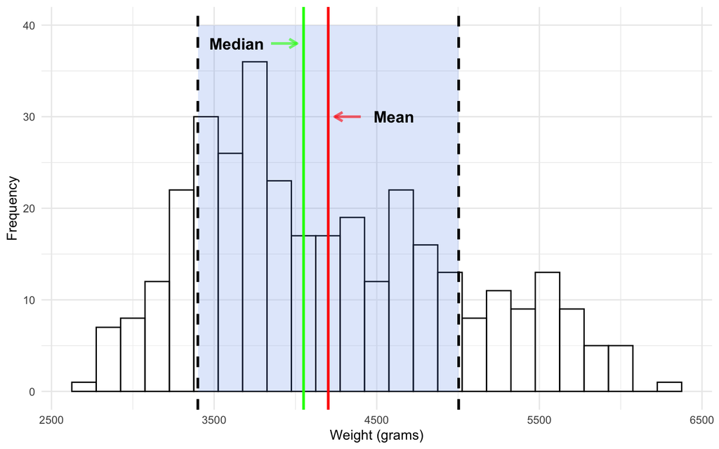

```r
penguin_plot +
  geom_vline(
    xintercept = mean_weight,
    color = "red", size = 1
  ) +
  geom_vline(
    xintercept = median_weight,
    color = "green", size = 1
  ) +
  geom_vline(
    xintercept = c(sd_below, sd_above),
    color = "black", linetype = "dashed", size = 1
  ) +
  theme_minimal() +
  labs(x = "Weight (grams)", y = "Frequency")
```

### EXERCISE 8: Describe the histogram

Here, describe what you see above.

## GGPLOT2

In this section, you will practice making and cleaning plots with ggplot2.

### EXERCISE 9: Scatterplot 1

Create a scatterplot showing the relationship between `bill_length_mm` and `bill_depth_mm`. Inside the aesthetic, color by penguin `island` residence. Add a theme as well as labels for: x, y, and color.

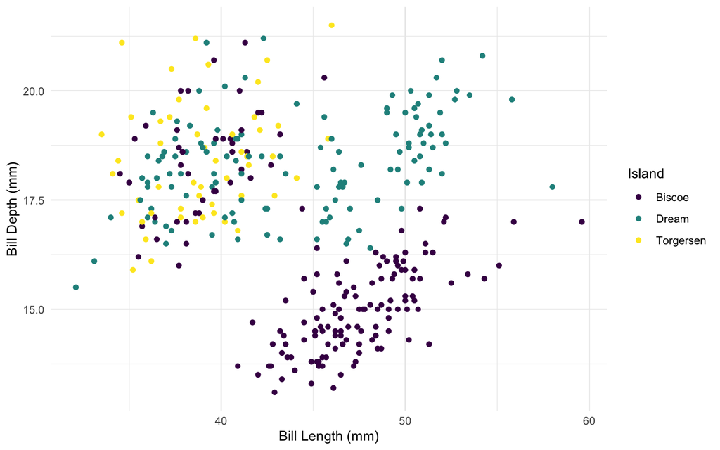

```r
ggplot(penguins, aes(x = bill_length_mm, y = bill_depth_mm,
                     color = island)) +
  geom_point() +
  theme_minimal() +
  scale_color_viridis(discrete = T) +
  labs(x = "Bill Length (mm)", y = "Bill Depth (mm)",
       color = "Island")
```

### EXERCISE 10: Scatterplot 1 Interpretation

Interpret what you see in the scatterplot above.

### EXERCISE 11: Scatterplot 2

Create a scatterplot showing the relationship between `flipper_length_mm` and `body_mass_g`. Inside the aesthetic, color by penguin `sex`. Add a theme as well as labels for: x, y, and color.

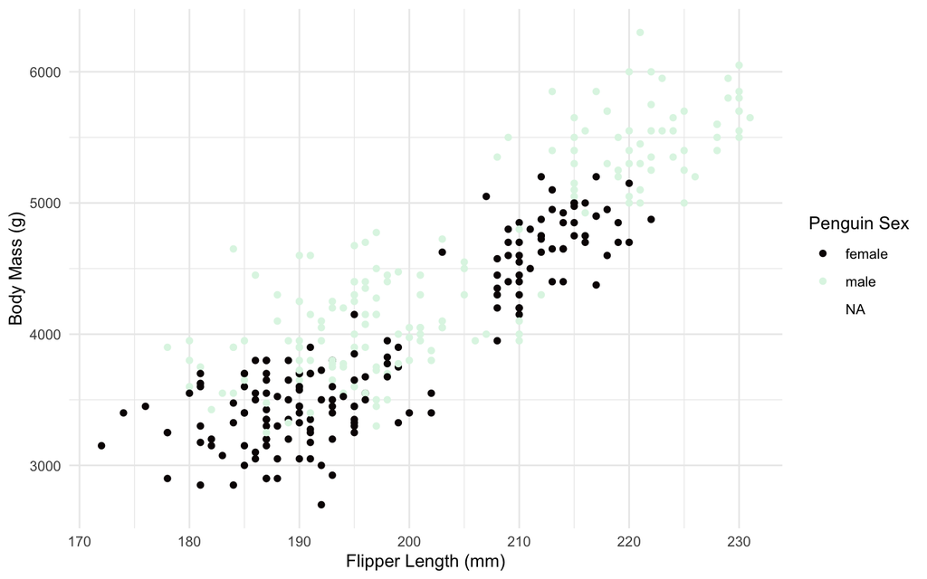

```r
ggplot(penguins, aes(x = flipper_length_mm, y = body_mass_g,
                     color = sex)) +
  geom_point() +
  theme_minimal() +
  scale_color_viridis(option = "mako", discrete = T) +
  labs(x = "Flipper Length (mm)", y = "Body Mass (g)",
       color = "Penguin Sex")
```

### EXERCISE 12: Scatterplot 2 Interpretation

Interpret what you see in the scatterplot above.

### EXERCISE 13: Barplot 1

Create a barplot showing the relationship between penguin `island` residence and `body_mass_g`. Inside the aesthetic, fill by penguin `sex` residence. Add a theme as well as labels for: x, y, and fill. You will need to use `stat_summary` to create the barplot with the mean.

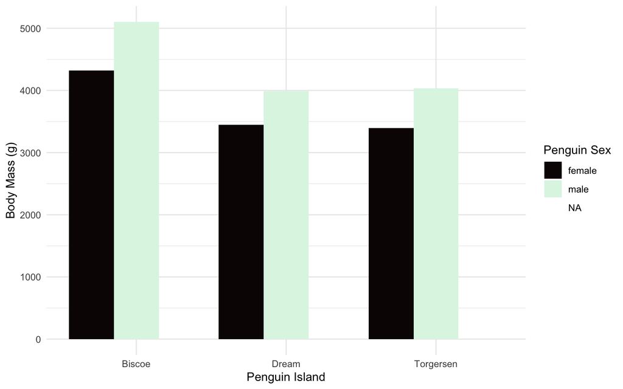

```r
ggplot(penguins, aes(x = island, y = body_mass_g,
                     fill = sex)) +
  stat_summary(fun = "mean", geom = "bar",
               position = "dodge") +
  theme_minimal() +
  scale_fill_viridis(option = "mako", discrete = T) +
  labs(x = "Penguin Island", y = "Body Mass (g)",
       fill = "Penguin Sex")
```

### EXERCISE 14: Barplot Interpretation

Interpret what you see in the barplot above.

## Correlations

### EXERCISE 15: Correlation 1

Using `cor.test()` run a correlation between `bill_depth_mm` and `bill_length_mm`.

```r
cor.test(penguins$bill_depth_mm, penguins$bill_length_mm)
```

```
##
##  Pearson's product-moment correlation
##
## data:  penguins$bill_depth_mm and penguins$bill_length_mm
## t = -4.4591, df = 340, p-value = 1.12e-05
## alternative hypothesis: true correlation is not equal to 0
## 95 percent confidence interval:
##  -0.3328072 -0.1323004
## sample estimates:
##        cor
## -0.2350529
```

### EXERCISE 16: Correlation 1 Interpretation

Interpret the correlation output from above.

### EXERCISE 17: Correlation 2

Using `cor.test()` run a correlation between `body_mass_g` and `flipper_length_mm`.

```r
cor.test(penguins$body_mass_g, penguins$flipper_length_mm)
```

```
##
##  Pearson's product-moment correlation
##
## data:  penguins$body_mass_g and penguins$flipper_length_mm
## t = 32.722, df = 340, p-value < 2.2e-16
## alternative hypothesis: true correlation is not equal to 0
## 95 percent confidence interval:
##  0.843041 0.894599
## sample estimates:
##       cor
## 0.8712018
```

### EXERCISE 18: Correlation 2 Interpretation

Interpret the correlation output from above.

## Scale Creation

### EXERCISE 19: Scale Items

I want to create a scale on love of all things Disney! Your final exercise is to come up with 5 statements and/or questions for this new scale. You are required to come up with at least 2 reverse-scored items. The statements/questions must be able to be responded to on a scale of 1-7, with 1 = strongly disagree, 4 = neither agree/nor disagree, and 7 = strongly agree.